# DATA624_HW4

John Ferrara

2025-03-01

## Homework 4

Do problems 3.1 and 3.2 in the Kuhn and Johnson book Applied Predictive Modeling. Please submit your Rpubs link along with your .pdf for your run code.

### 3.1.

The UC Irvine Machine Learning Repository6 contains a data set related to glass identification. The data consist of 214 glass samples labeled as one of seven class categories. There are nine predictors, including the refractive index and percentages of eight elements: Na, Mg, Al, Si, K, Ca, Ba, and Fe. The data can be accessed via:

```r
data(Glass)
print(str(Glass))
```

```
## 'data.frame':    214 obs. of  10 variables:
##  $ RI  : num  1.52 1.52 1.52 1.52 1.52 ...
##  $ Na  : num  13.6 13.9 13.5 13.2 13.3 ...
##  $ Mg  : num  4.49 3.6 3.55 3.69 3.62 3.61 3.6 3.61 3.58 3.6 ...
##  $ Al  : num  1.1 1.36 1.54 1.29 1.24 1.62 1.14 1.05 1.37 1.36 ...
##  $ Si  : num  71.8 72.7 73 72.6 73.1 ...
##  $ K   : num  0.06 0.48 0.39 0.57 0.55 0.64 0.58 0.57 0.56 0.57 ...
##  $ Ca  : num  8.75 7.83 7.78 8.22 8.07 8.07 8.17 8.24 8.3 8.4 ...
##  $ Ba  : num  0 0 0 0 0 0 0 0 0 0 ...
##  $ Fe  : num  0 0 0 0 0 0.26 0 0 0 0.11 ...
##  $ Type: Factor w/ 6 levels "1","2","3","5",..: 1 1 1 1 1 1 1 1 1 1 ...
## NULL
```

#### (a) Using visualizations, explore the predictor variables to understand their distributions as well as the relationships between predictors.

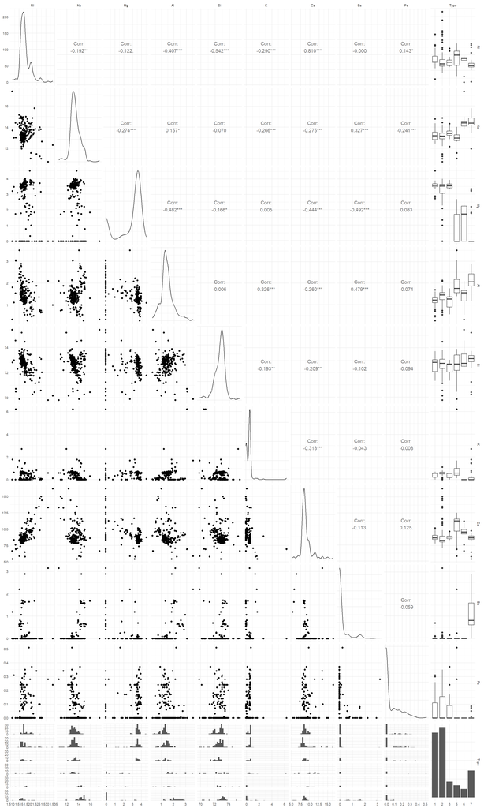

```r
## Using GGpairs to plot everythign for the varibles
ggpairs(Glass, progress = FALSE) +  theme_minimal(base_size=9)
```

#### (b) Do there appear to be any outliers in the data? Are any predictors skewed?

## Based on the ggpairs plot and the custom histogram and skewness values below there is are skewed predictors here. The following predictors have right skewed data: RI, K, Ca, Ba, Fe. The following predictors have left skewed data: Mg, and Si. THose columns that have skewness but it may be a bit varied, or not too visible, are: Al. Additionally, based on the histograms the predictors that seem to have outliers are: RI, K, Ca, Ba and Fe.

```
## [1] "RI"
```

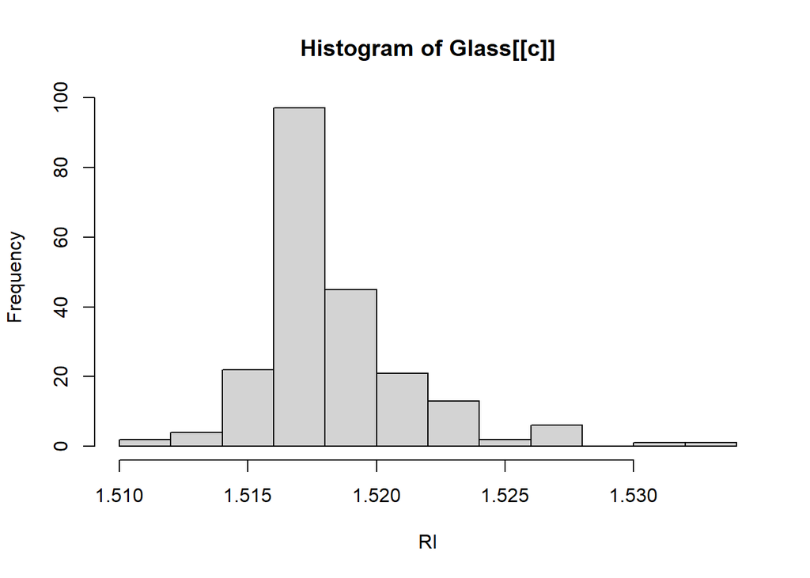

```
## [1] "Na"
```

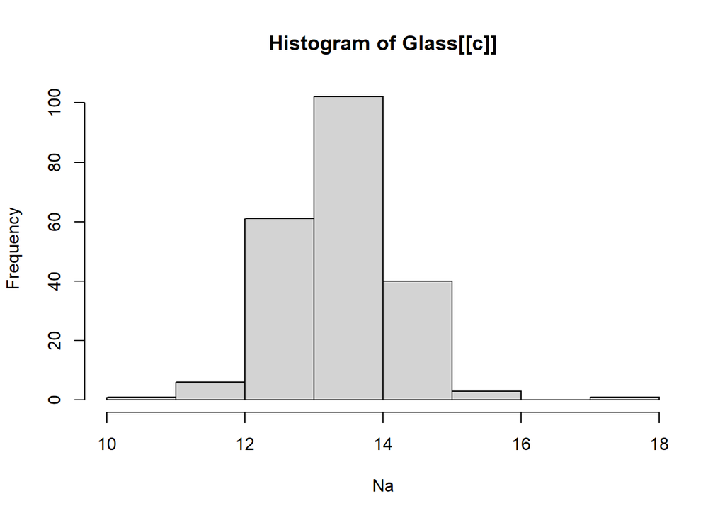

```
## [1] "Mg"
```

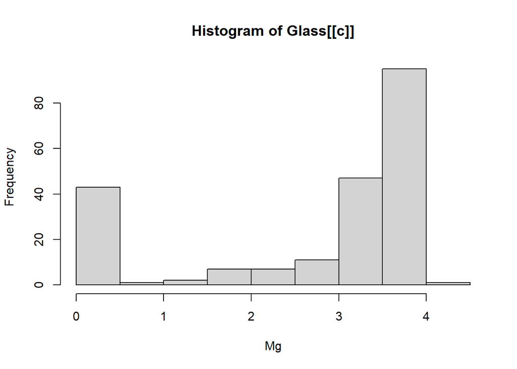

```
## [1] "Al"
```

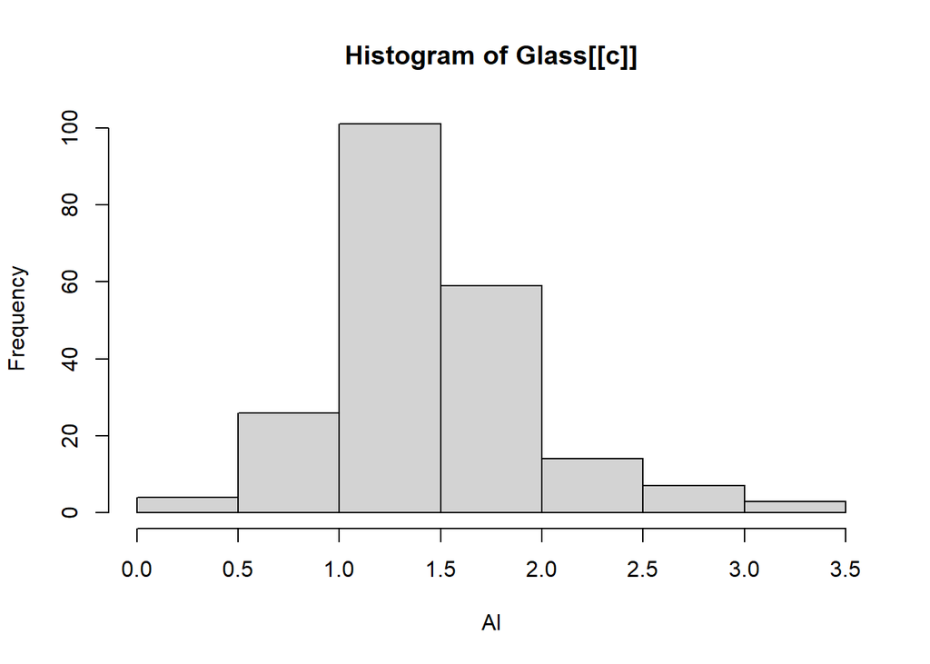

```
## [1] "Si"
```

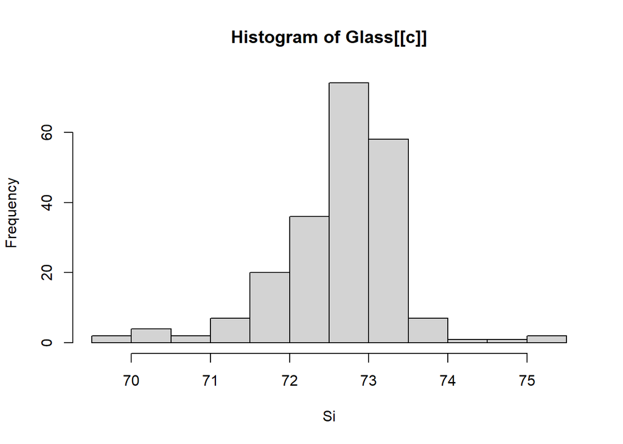

```
## [1] "K"
```

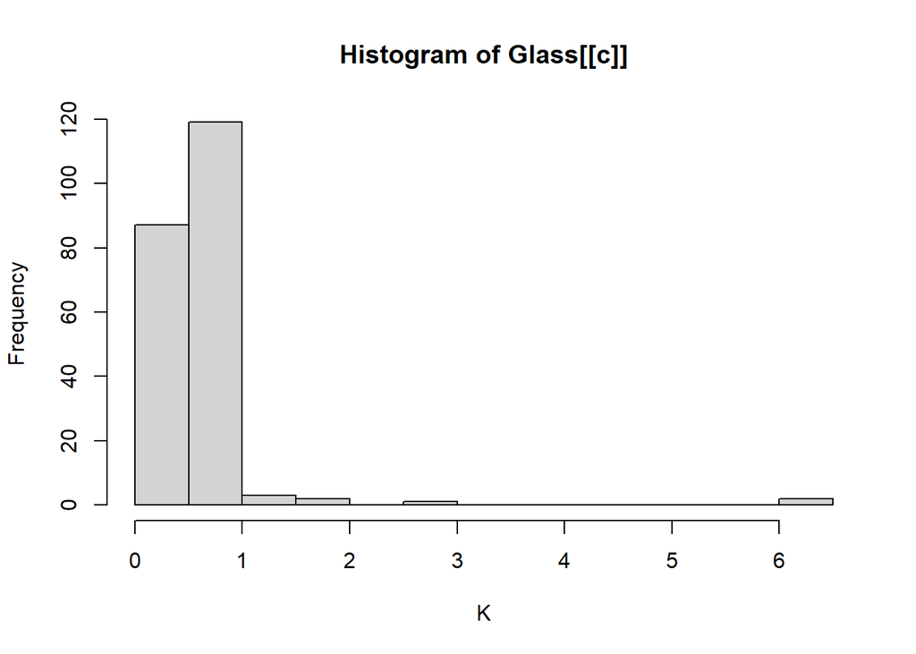

```
## [1] "Ca"
```

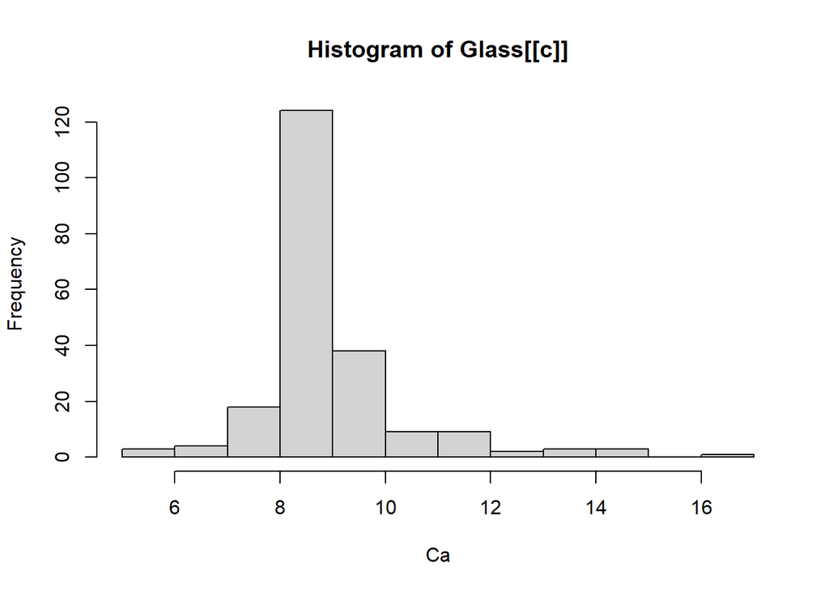

```
## [1] "Ba"
```

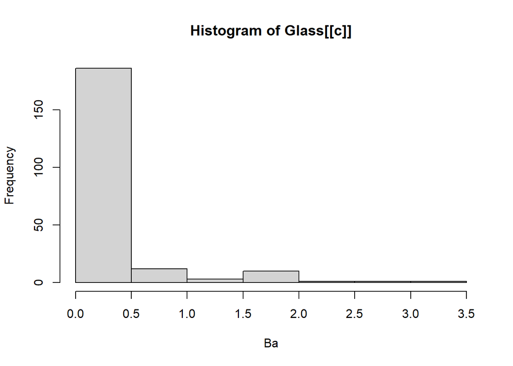

```
## [1] "Fe"
```

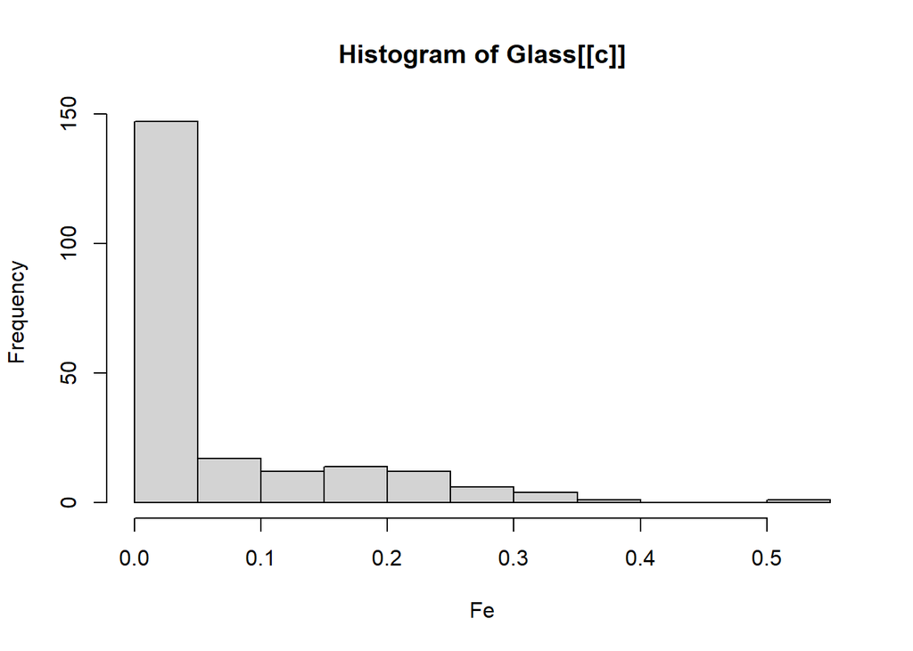

```
## [1] "Type column is not numeric"
```

```r
## Plotting direct histograms for this data to look at skewness.

for (c in colnames(Glass)) {
  if (c == 'Type'){
    print("Type column is not numeric")
    NULL
  }
  else{
  print(c)
  hist(Glass[[c]],xlab = c)

  }
}
```

```r
## SKEWNESS
print("RI")
```

```
## [1] "RI"
```

```r
print(skewness(Glass$RI))
```

```
## [1] 1.614015
```

```r
print("Na")
```

```
## [1] "Na"
```

```r
print(skewness(Glass$Na))
```

```
## [1] 0.4509917
```

```r
print("Mg")
```

```
## [1] "Mg"
```

```r
print(skewness(Glass$Mg))
```

```
## [1] -1.144465
```

```r
print("Al")
```

```
## [1] "Al"
```

```r
print(skewness(Glass$Al))
```

```
## [1] 0.9009179
```

```r
print("Si")
```

```
## [1] "Si"
```

```r
print(skewness(Glass$Si))
```

```
## [1] -0.7253173
```

```r
print("K")
```

```
## [1] "K"
```

```r
print(skewness(Glass$K))
```

```
## [1] 6.505636
```

```r
print("Ca")
```

```
## [1] "Ca"
```

```r
print(skewness(Glass$Ca))
```

```
## [1] 2.032677
```

```r
print("Ba")
```

```
## [1] "Ba"
```

```r
print(skewness(Glass$Ba))
```

```
## [1] 3.392431
```

```r
print("Fe")
```

```
## [1] "Fe"
```

```r
print(skewness(Glass$Fe))
```

```
## [1] 1.742007
```

####(c) Are there any relevant transformations of one or more predictors that might improve the classification model? Yes, i used Box Cox on each of the predictors in order to transform and help their distrbutions. See below.

```r
# Transformations for the skewed variables.
#install.packages("caret")
library(caret)
```

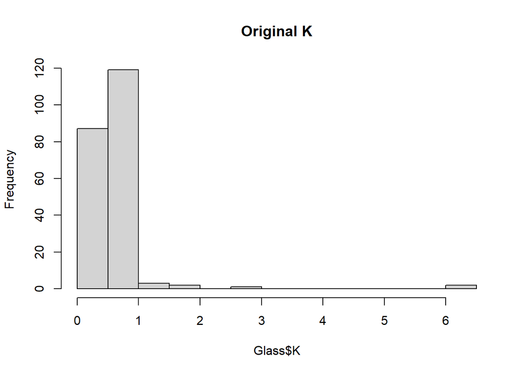

```r
trans_glass <- Glass

## K
hist(Glass$K, main="Original K")
```

```r
trans_k<- BoxCoxTrans(Glass$K+1) # Taking care of zeros
print(trans_k$lambda) ## Optimal Lambda is -1
```

```
## [1] -1
```

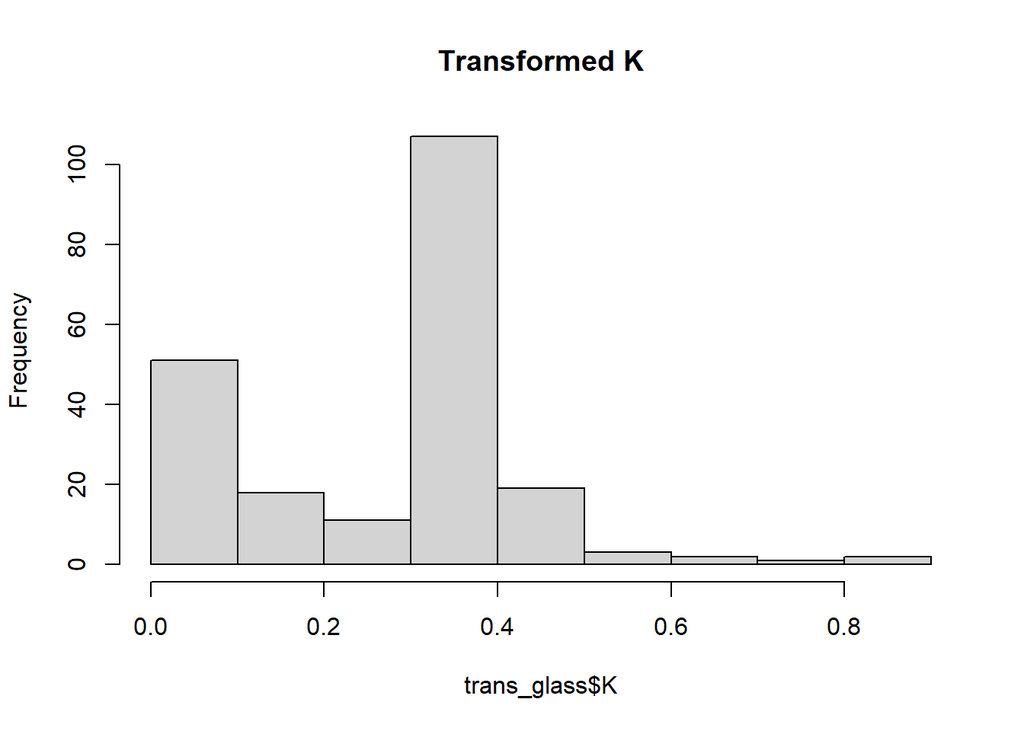

```r
trans_glass$K <- ((trans_glass$K + 1)^trans_k$lambda - 1) / trans_k$lambda
hist(trans_glass$K, main="Transformed K")
```

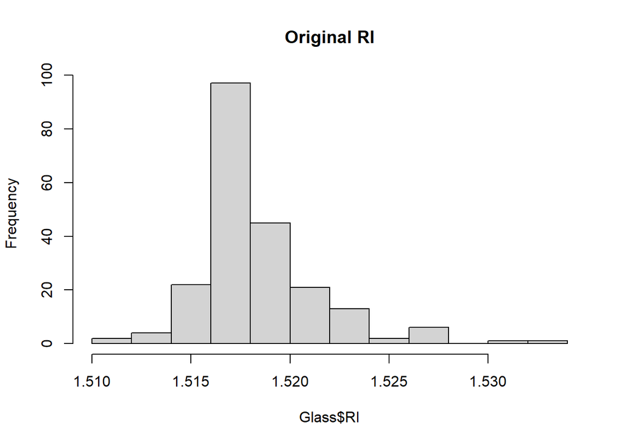

```r
## RI
hist(Glass$RI, main="Original RI")
```

```r
trans_RI<- BoxCoxTrans(Glass$RI+1) # Taking care of zeros
print(trans_RI$lambda) ## Optimal Lambda is -2
```

```
## [1] -2
```

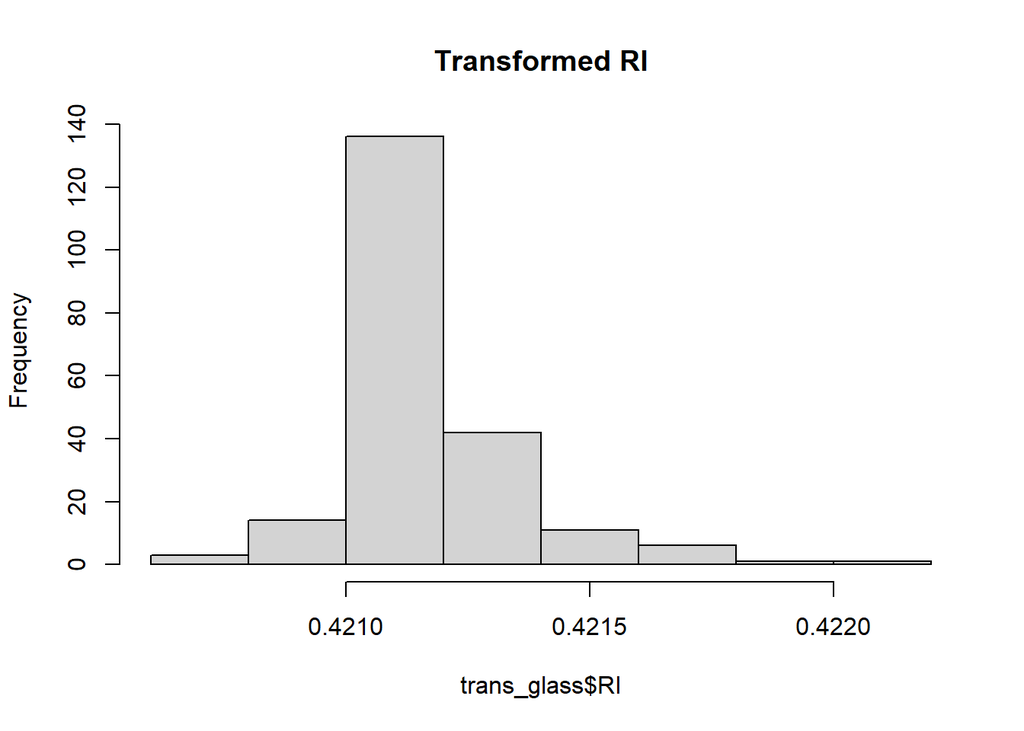

```r
trans_glass$RI <- ((trans_glass$RI + 1)^trans_RI$lambda - 1) / trans_RI$lambda
hist(trans_glass$RI, main="Transformed RI")
```

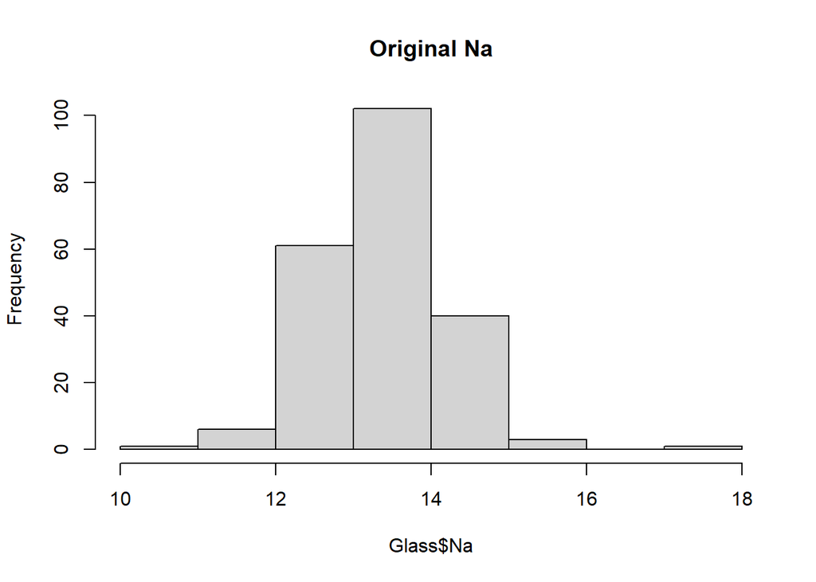

```r
## Na
hist(Glass$Na, main="Original Na")
```

```r
trans_Na<- BoxCoxTrans(Glass$Na+1) # Taking care of zeros
print(trans_Na$lambda) ## Optimal Lambda is -0.2
```

```
## [1] -0.2
```

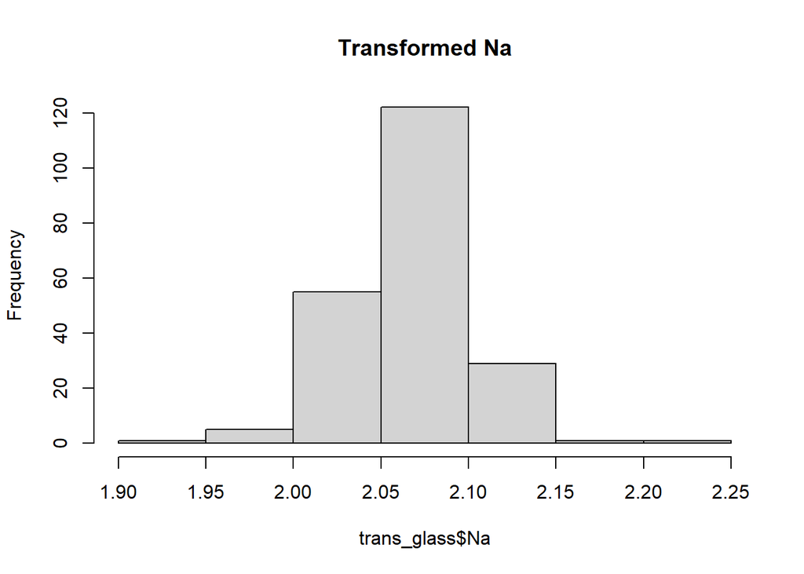

```r
trans_glass$Na <- ((trans_glass$Na + 1)^trans_Na$lambda - 1) / trans_Na$lambda
hist(trans_glass$Na, main="Transformed Na")
```

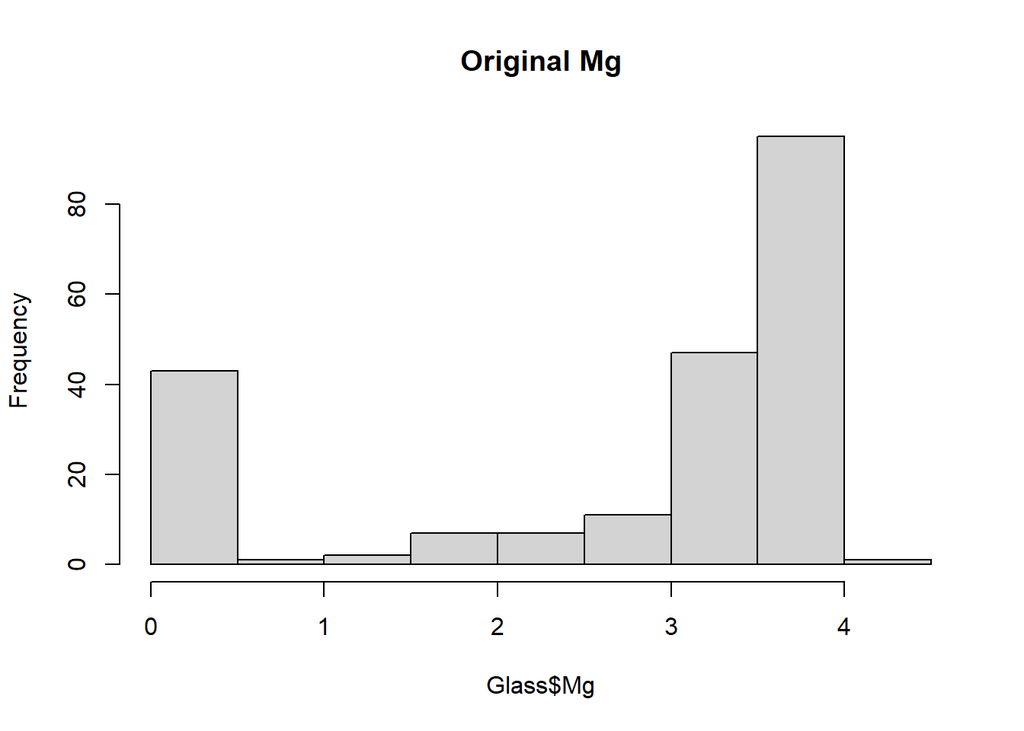

```r
## Mg
hist(Glass$Mg, main="Original Mg")
```

```r
trans_Mg<- BoxCoxTrans(Glass$Mg+1) # Taking care of zeros
print(trans_Mg$lambda) ## Optimal Lambda is 2
```

```
## [1] 2
```

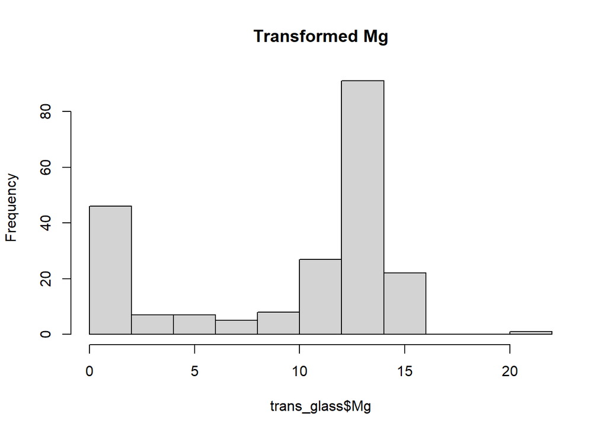

```r
trans_glass$Mg <- (trans_glass$Mg)^2
hist(trans_glass$Mg, main="Transformed Mg")
```

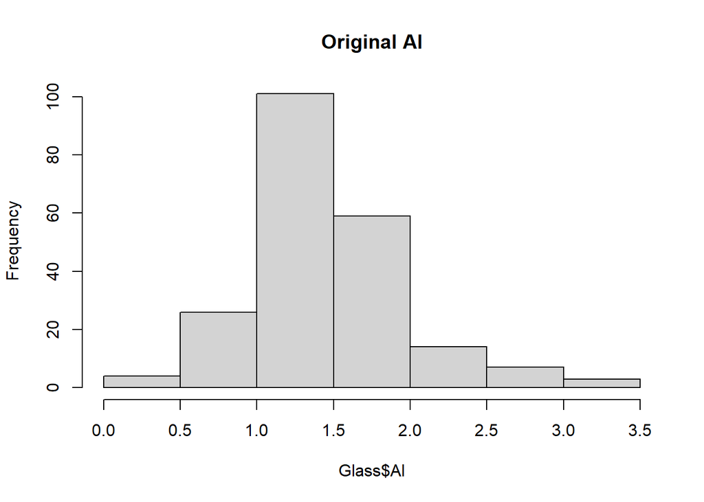

```r
## Al
hist(Glass$Al, main="Original Al")
```

```r
trans_Al<- BoxCoxTrans(Glass$Al+1) # Taking care of zeros
print(trans_Al$lambda) ## Optimal Lambda is
```

```
## [1] 0
```

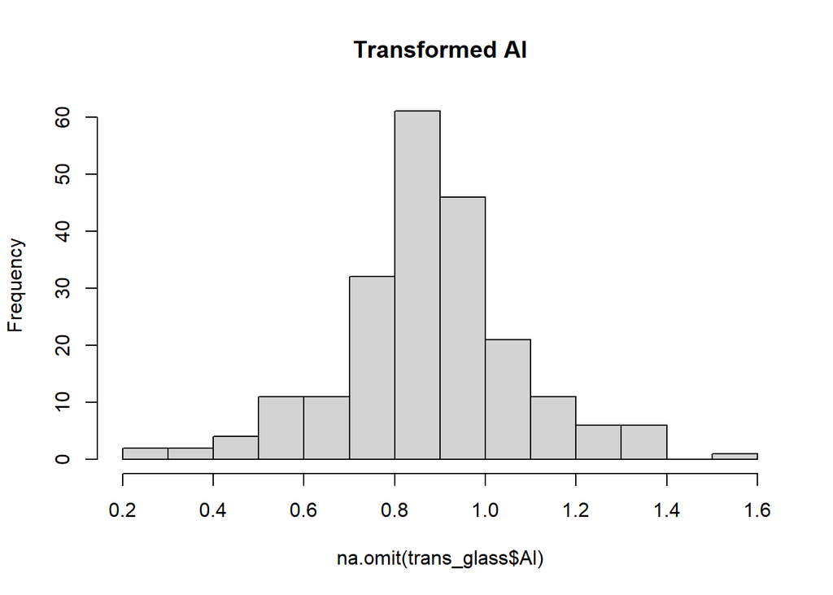

```r
trans_glass$Al <- log(trans_glass$Al + 1)
hist(na.omit(trans_glass$Al), main="Transformed Al")
```

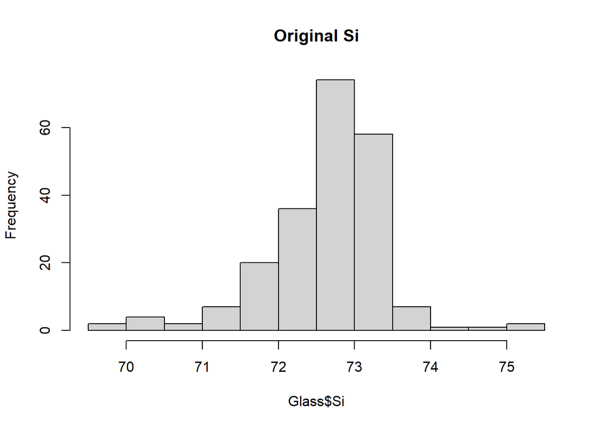

```r
## Si
hist(Glass$Si, main="Original Si")
```

```r
trans_Si <- BoxCoxTrans(Glass$Si + 1)
print(trans_Si$lambda)  ##2
```

```
## [1] 2
```

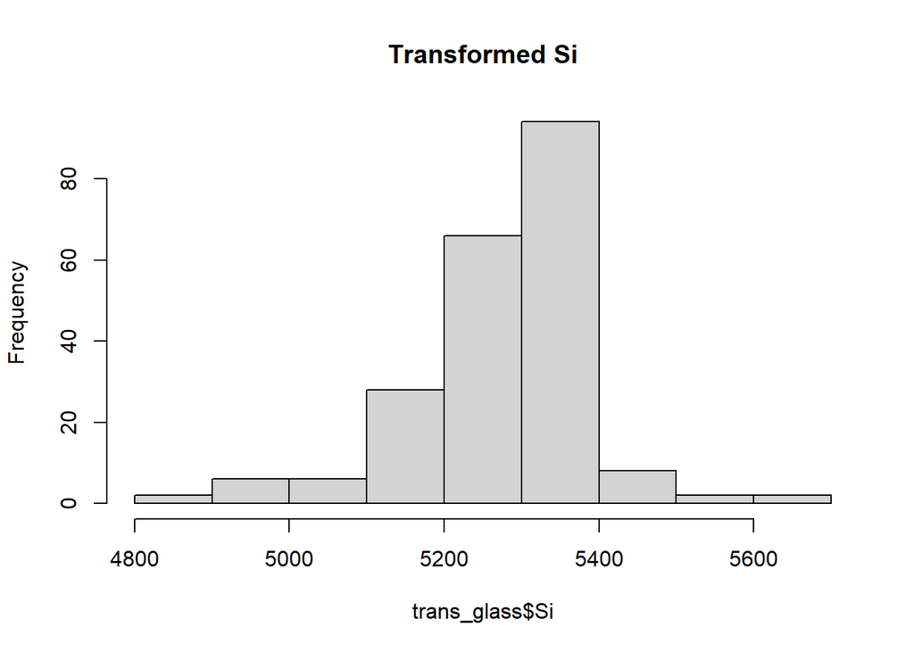

```r
trans_glass$Si <- (trans_glass$Si)^2
hist(trans_glass$Si, main="Transformed Si")
```

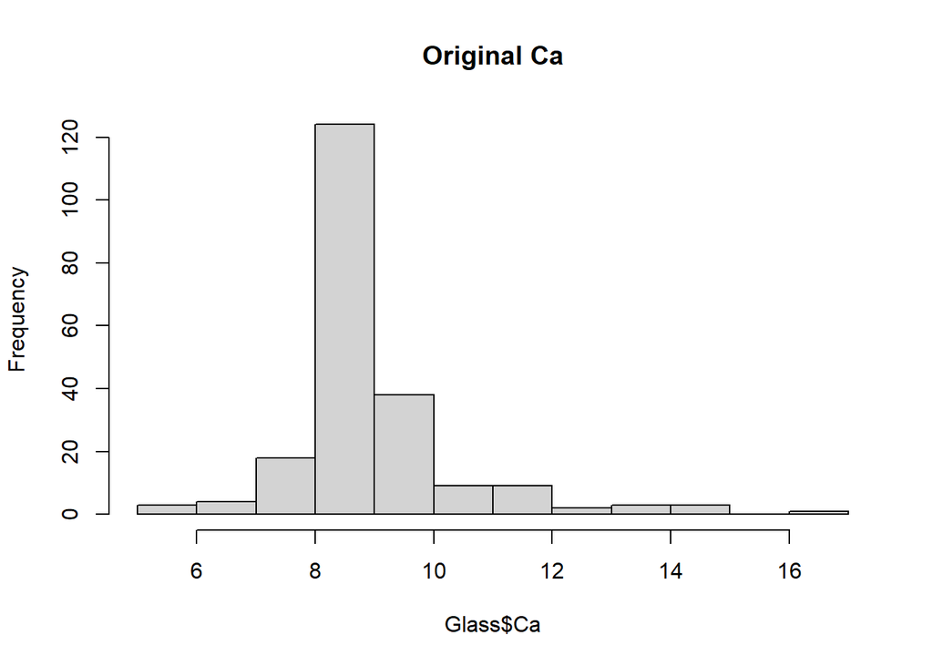

```r
## Ca
hist(Glass$Ca, main="Original Ca")
```

```r
trans_Ca <- BoxCoxTrans(Glass$Ca + 1)
print(trans_Ca$lambda)
```

```
## [1] -1.4
```

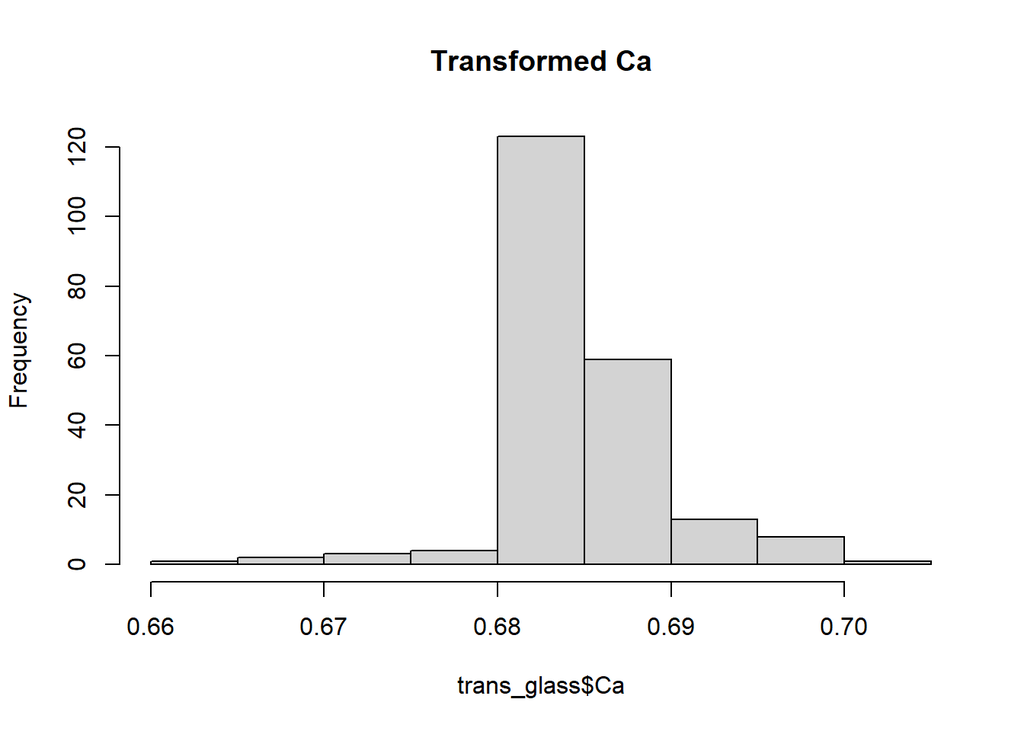

```r
trans_glass$Ca <- ((Glass$Ca + 1)^trans_Ca$lambda - 1) / trans_Ca$lambda
hist(trans_glass$Ca, main="Transformed Ca")
```

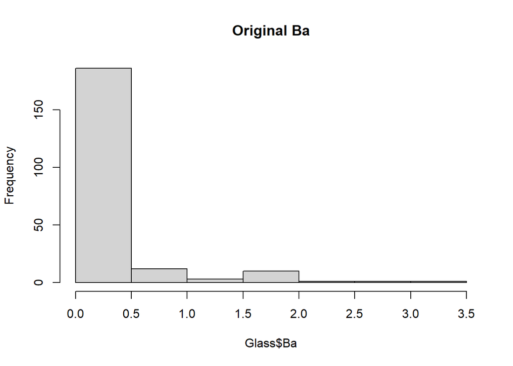

```r
## Ba
hist(Glass$Ba, main="Original Ba")
```

```r
trans_Ba <- BoxCoxTrans(Glass$Ba + 1)
print(trans_Ba$lambda)
```

```
## [1] -2
```

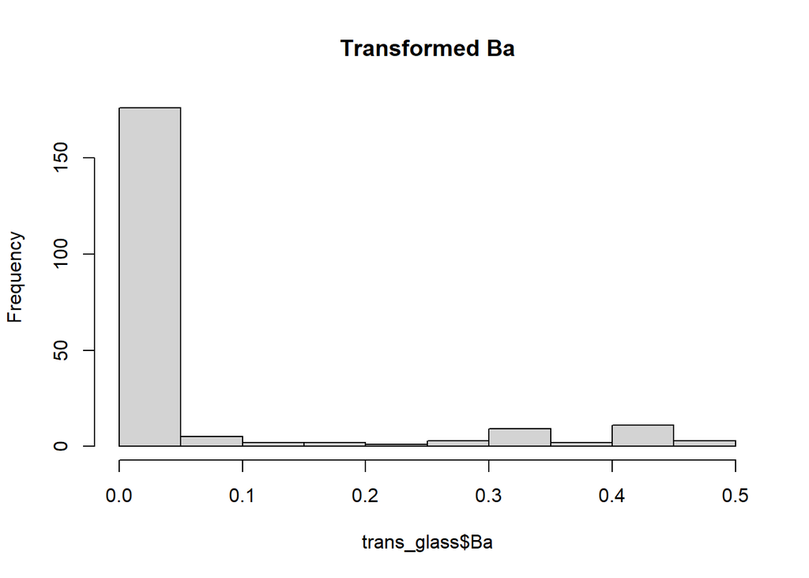

```r
trans_glass$Ba <- ((Glass$Ba + 1)^trans_Ba$lambda - 1) / trans_Ba$lambda
hist(trans_glass$Ba, main="Transformed Ba")
```

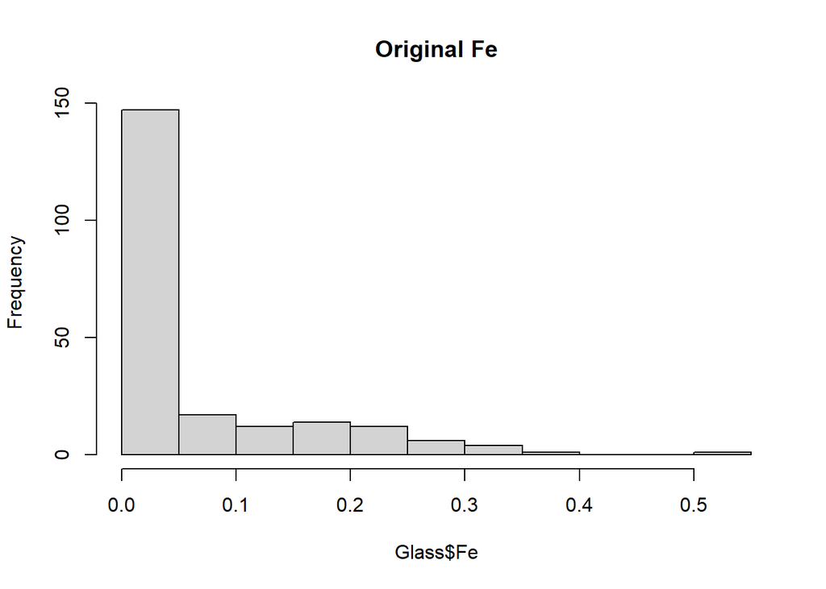

```r
## Fe
hist(Glass$Fe, main="Original Fe")
```

```r
trans_Fe <- BoxCoxTrans(Glass$Fe + 1)
print(trans_Fe$lambda)
```

```
## [1] -2
```

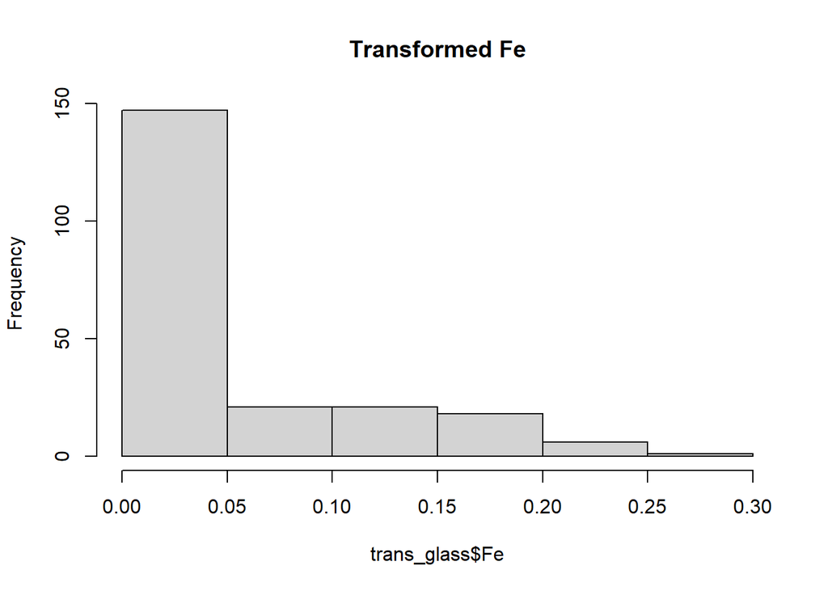

```r
trans_glass$Fe <- ((Glass$Fe + 1)^trans_Fe$lambda - 1) / trans_Fe$lambda
hist(trans_glass$Fe, main="Transformed Fe")
```

### 3.2.

The soybean data can also be found at the UC Irvine Machine Learning Repository. Data were collected to predict disease in 683 soybeans. The 35 predictors are mostly categorical and include information on the environmental conditions (e.g., temperature, precipitation) and plant conditions (e.g., left spots, mold growth). The outcome labels consist of 19 distinct classes.The data can be loaded via:

```r
#library(mlbench)
data(Soybean)
## See ?Soybean for details
#?Soybean
```

#### (a) Investigate the frequency distributions for the categorical predictors. Are any of the distributions degenerate in the ways discussed earlier in this chapter?

Yes, many of the columns in this table do not have a large amount of variability, the data is numeric categorical dummy variables. Therefore it’s a hurdle when attempting to model any type of variability.

```r
#head(Soybean)
for (c in colnames(Soybean)){
  print(c)
 print(table(Soybean[[c]]))
}
```

```
## [1] "Class"
##
##                2-4-d-injury         alternarialeaf-spot
##                          16                          91
##                 anthracnose            bacterial-blight
##                          44                          20
##           bacterial-pustule                  brown-spot
##                          20                          92
##              brown-stem-rot                charcoal-rot
##                          44                          20
##               cyst-nematode diaporthe-pod-&-stem-blight
##                          14                          15
##       diaporthe-stem-canker                downy-mildew
##                          20                          20
##          frog-eye-leaf-spot            herbicide-injury
```

[output cut: 147 more lines]

```r
#The following columnd only have binary values, that is there is only 1 or 0 values present in the column:
#  plant.stand
#  hail
#  plant.growth
#  leaves
#  leaf.shread
#  leaf.malf
#  stem
#  lodging
#  fruiting.bodies
#  mycellium
#  sclerotia
#  seed
#  seed.discolor
#  seed.size
#  shriveling

#These binary columns also have a disproportionate amount of zeros when compared to 1's, except for plant.stand, stem,  plant.growth.
# plant.leaf has many more 1 values than 0.
```

#### (b) Roughly 18 % of the data are missing. Are there particular predictors that are more likely to be missing? Is the pattern of missing data related to the classes?

The predictor columns that are most likely to be null are: hail, sever, seet.tmt, lodging. Those with no nulls are:Class, Leaves Those with nulls, but have the fewest amount: date,area.dam, crop.hist,stem,plant.growth.

When looking at the Class the nulls are mostly limited to a handfull of class values, so these should probably be removed. The class values that have all of the nulls are: phytophthora-rot, 2-4-d-injury,cyst-nematode,diaporthe-pod-&-stem-blight, and herbicide-injury.

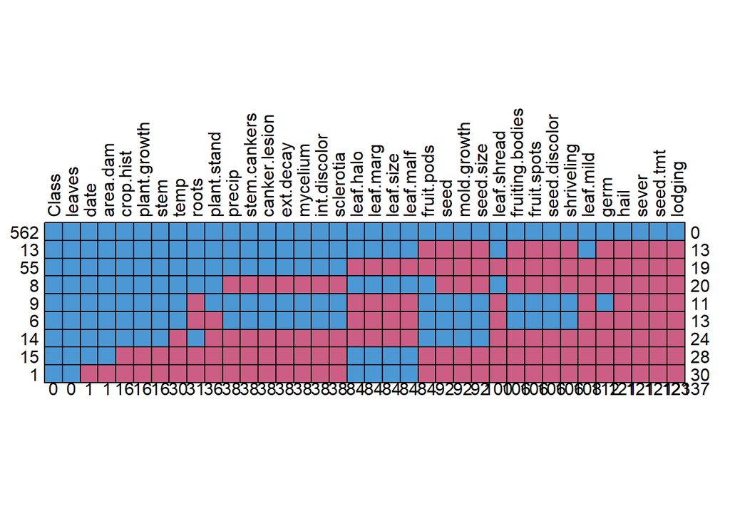

```
##     Class leaves date area.dam crop.hist plant.growth stem temp roots
## 562     1      1    1        1         1            1    1    1     1
## 13      1      1    1        1         1            1    1    1     1
## 55      1      1    1        1         1            1    1    1     1
## 8       1      1    1        1         1            1    1    1     1
## 9       1      1    1        1         1            1    1    1     0
## 6       1      1    1        1         1            1    1    1     0
## 14      1      1    1        1         1            1    1    0     1
## 15      1      1    1        1         0            0    0    0     0
## 1       1      1    0        0         0            0    0    0     0
##         0      0    1        1        16           16   16   30    31
##     plant.stand precip stem.cankers canker.lesion ext.decay mycelium
## 562           1      1            1             1         1        1
## 13            1      1            1             1         1        1
## 55            1      1            1             1         1        1
```

[output cut: 40 more lines]

```r
## Using the MICE package to display the null coverage.
md.pattern(Soybean,rotate.names = TRUE)
```

```r
## Most nulls: hail sever seet.tmt lodging

## Least NUlls: date,area.dam, crop.hist,stem,plant.growth

## NO Nulls : Class, Leaves
missing_counts <- Soybean |>
  group_by(Class) |>
  summarise(across(everything(), ~sum(is.na(.)), .names = "missing_{col}"))

missing_counts <- missing_counts %>%
  mutate(total_nulls = rowSums(across(starts_with("missing_"))))

print(nrow(Soybean)) #683
```

```
## [1] 683
```

```r
print(missing_counts |> select(Class, total_nulls) |>arrange(desc(total_nulls) ))
```

```
## # A tibble: 19 × 2
##    Class                       total_nulls
##    <fct>                             <dbl>
##  1 phytophthora-rot                   1214
##  2 2-4-d-injury                        450
##  3 cyst-nematode                       336
##  4 diaporthe-pod-&-stem-blight         177
##  5 herbicide-injury                    160
##  6 alternarialeaf-spot                   0
##  7 anthracnose                           0
##  8 bacterial-blight                      0
##  9 bacterial-pustule                     0
## 10 brown-spot                            0
## 11 brown-stem-rot                        0
## 12 charcoal-rot                          0
## 13 diaporthe-stem-canker                 0
## 14 downy-mildew                          0
## 15 frog-eye-leaf-spot                    0
## 16 phyllosticta-leaf-spot                0
## 17 powdery-mildew                        0
## 18 purple-seed-stain                     0
## 19 rhizoctonia-root-rot                  0
```

#### (c) Develop a strategy for handling missing data, either by eliminating predictors or imputation.

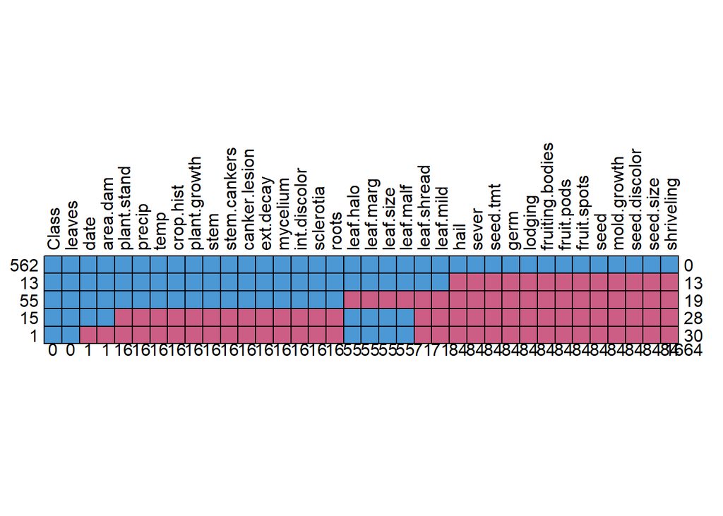

```
##     Class leaves date area.dam plant.stand precip temp crop.hist plant.growth
## 562     1      1    1        1           1      1    1         1            1
## 13      1      1    1        1           1      1    1         1            1
## 55      1      1    1        1           1      1    1         1            1
## 15      1      1    1        1           0      0    0         0            0
## 1       1      1    0        0           0      0    0         0            0
##         0      0    1        1          16     16   16        16           16
##     stem stem.cankers canker.lesion ext.decay mycelium int.discolor sclerotia
## 562    1            1             1         1        1            1         1
## 13     1            1             1         1        1            1         1
## 55     1            1             1         1        1            1         1
## 15     0            0             0         0        0            0         0
## 1      0            0             0         0        0            0         0
##       16           16            16        16       16           16        16
##     roots leaf.halo leaf.marg leaf.size leaf.malf leaf.shread leaf.mild hail
```

[output cut: 20 more lines]

```r
no_nulls <- Soybean |> filter(!Class %in% c("phytophthora-rot, 2-4-d-injury","cyst-nematode","diaporthe-pod-&-stem-blight","herbicide-injury"))
md.pattern(no_nulls,rotate.names = TRUE)
```

```r
nrow(no_nulls) #646
```

```
## [1] 646
```

```r
colSums(is.na(no_nulls)) # Max number of nulls in a column is 84.
```

```
##           Class            date     plant.stand          precip            temp
##               0               1              16              16              16
##            hail       crop.hist        area.dam           sever        seed.tmt
##              84              16               1              84              84
##            germ    plant.growth          leaves       leaf.halo       leaf.marg
##              84              16               0              55              55
##       leaf.size     leaf.shread       leaf.malf       leaf.mild            stem
##              55              71              55              71              16
##         lodging    stem.cankers   canker.lesion fruiting.bodies       ext.decay
##              84              16              16              84              16
##        mycelium    int.discolor       sclerotia      fruit.pods     fruit.spots
##              16              16              16              84              84
##            seed     mold.growth   seed.discolor       seed.size      shriveling
##              84              84              84              84              84
##           roots
##              16
```